# Formal Groups and Spectra

Formal group law stuff

- [Notes](https://math.mit.edu/juvitop/pastseminars/notes_2020_Spring/Levy.pdf)
- [Survey Paper](http://people.math.harvard.edu/~lurie/papers/survey.pdf)

## Formal Groups

### Basics

- Motivation: why should one care about formal groups?
  - Idea: substitute for Lie algebras in positive characteristic
  - Formal group and lie algebra carry the same info in char 0
  - Functor: LieGroups (or AlgGrp) → LieAlgebras factors through FormalGroups

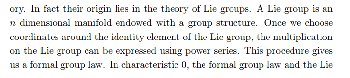

- Motivation: if a formal group were for sale, why might you buy it?

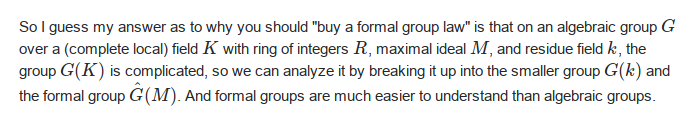

- What is a formal group law?

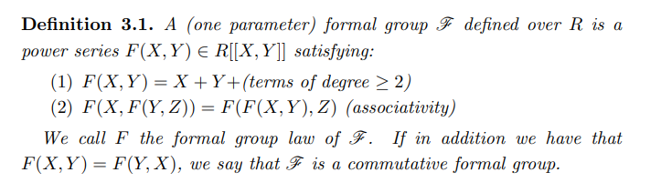

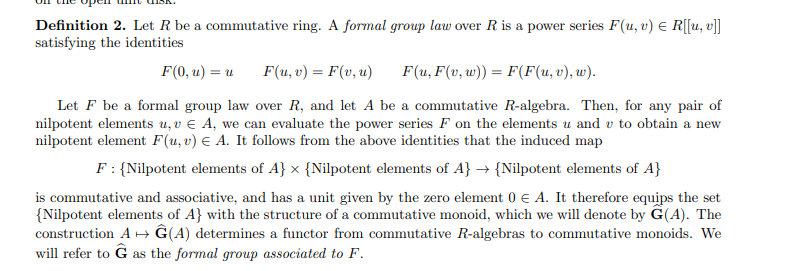

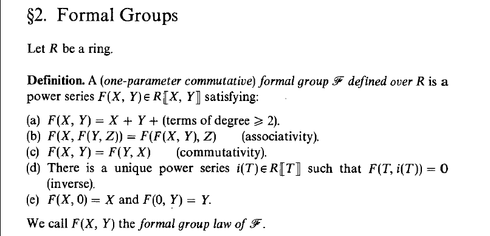

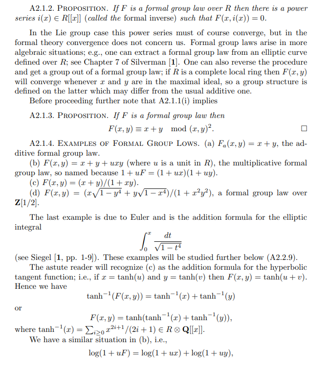

- Why is the group law called “formal”?

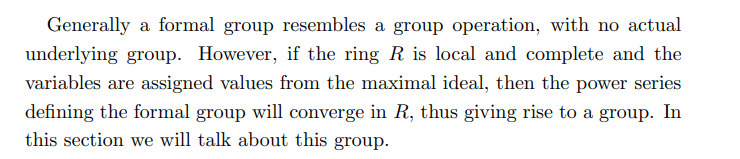

- How “should” one think of a formal group?

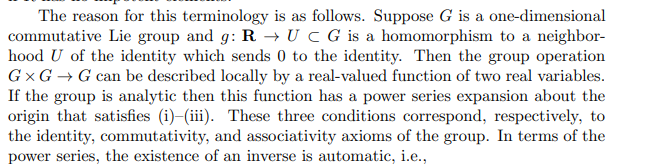

- What is a formal exponential and formal logarithm?

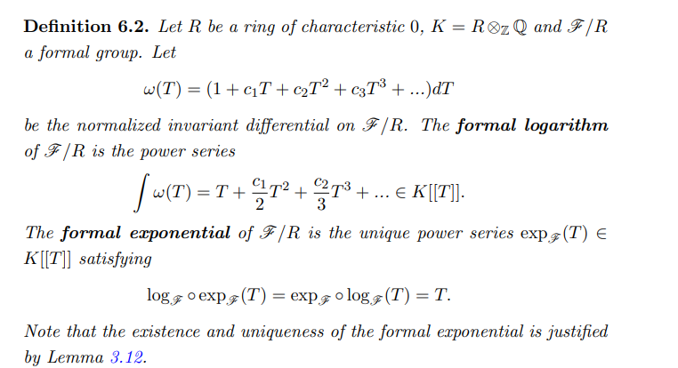

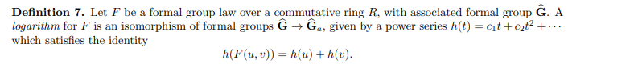

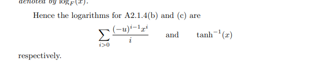

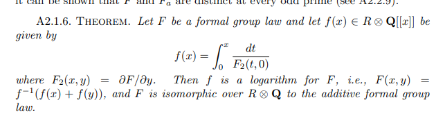

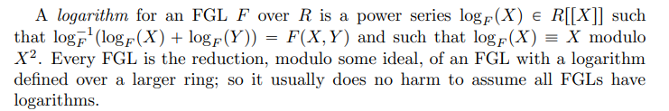

- What are examples of formal groups? What is a morphism? When are they isomorphic?

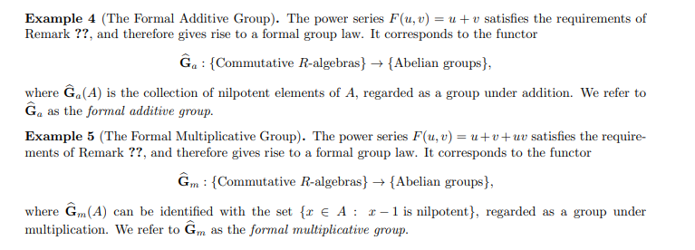

- What are the additive and multiplicative formal groups?

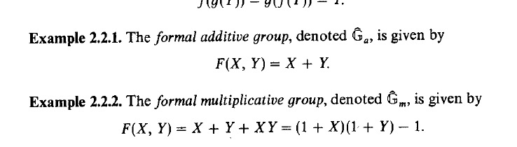

- How are the additive and multiplicative formal groups related?

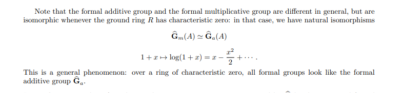

- What is the height of a formal group?

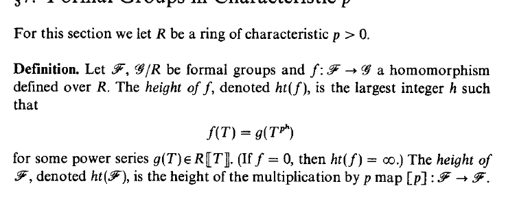

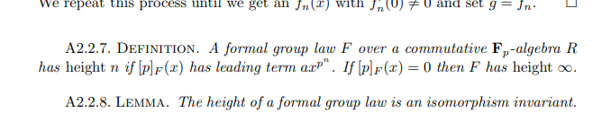

- How can one extend formal groups over R to R-algebras?

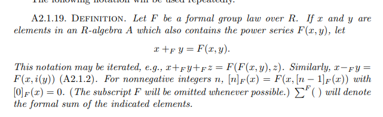

- What is the formal scheme interpretation of formal groups?

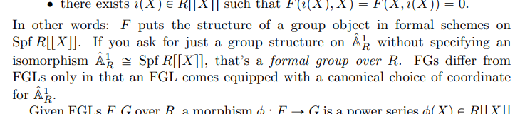

- How does iterated K-theory show up in the theory of formal groups?

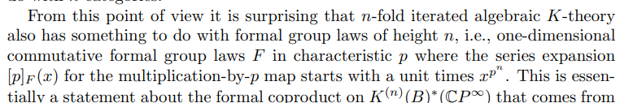

## Other Connections to Elliptic Curves

- What is the invariant differential of an elliptic curve?

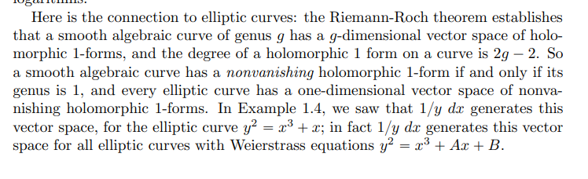

- How does one extract the formal group of an elliptic curve using differential forms?

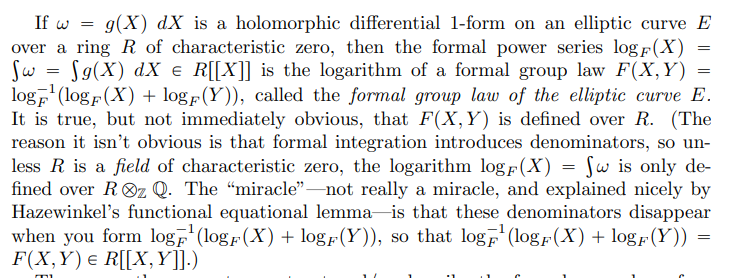

- How does the formal group of a curve relate to torsion and the Mordell-Weil theorem?

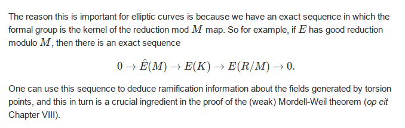

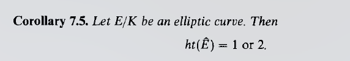

- What can a formal group tell you about your curve?

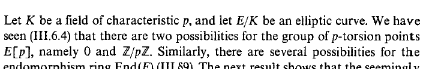

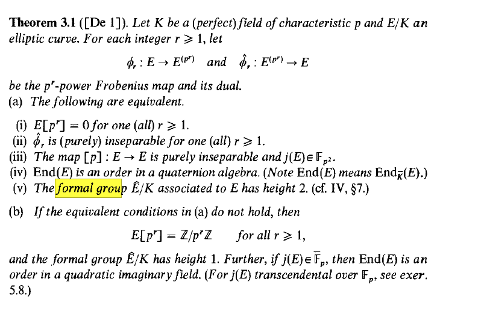